# Tomey Lab 4 Assignment - Landcover

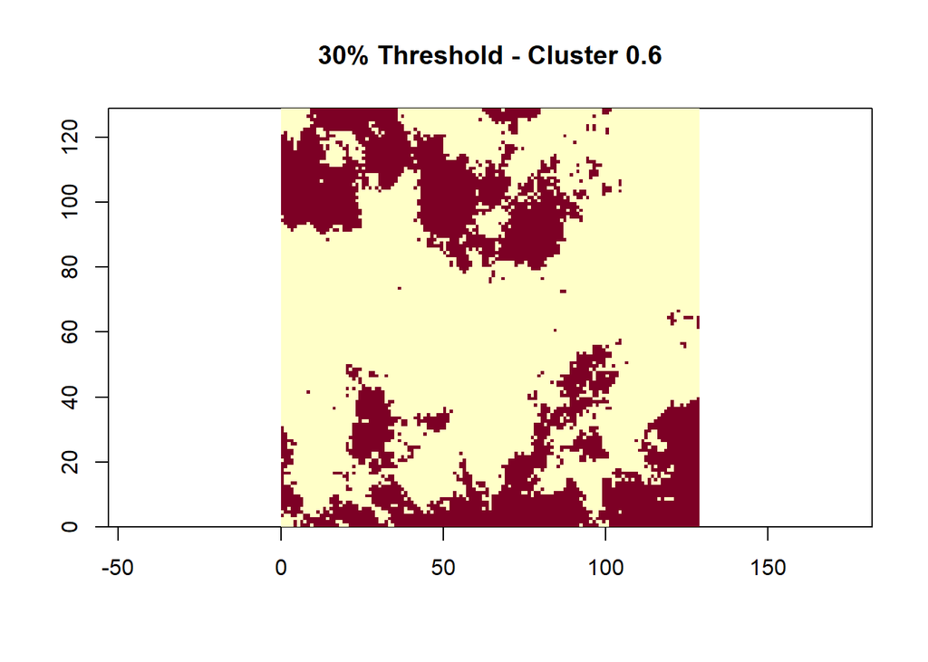

```r
thresholdv6 = quantile(as.matrix(voss6), prob = 0.3)
vossC6 = ifel(voss6 > thresholdv6, 0, 1)
image(vossC6, main = "30% Threshold - Cluster 0.6")
```

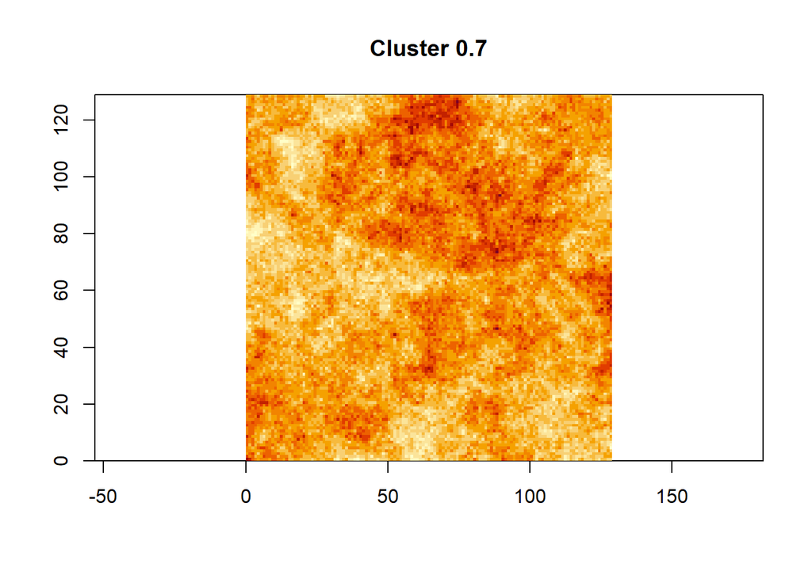

```r
# 7
voss7 = voss2d(g = 7, H = 0.7)
voss7 = rast(voss7$z)
image(voss1, main = "Cluster 0.7")
```

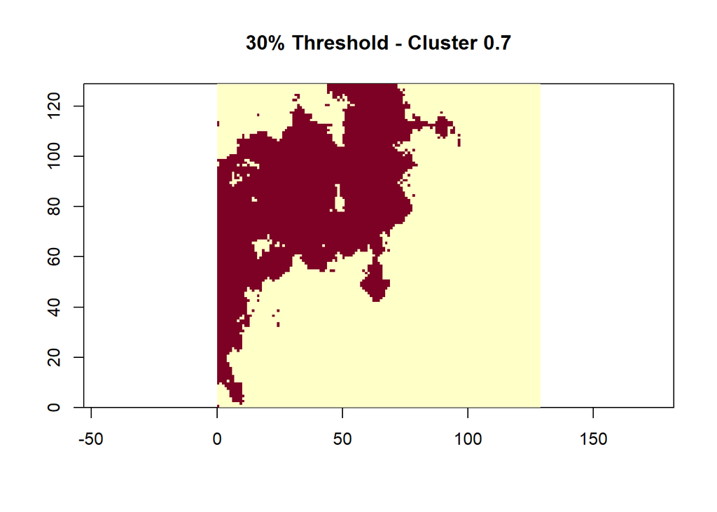

```r
thresholdv7 = quantile(as.matrix(voss7), prob = 0.3)
vossC7 = ifel(voss7 > thresholdv7, 0, 1)
image(vossC7, main = "30% Threshold - Cluster 0.7")
```

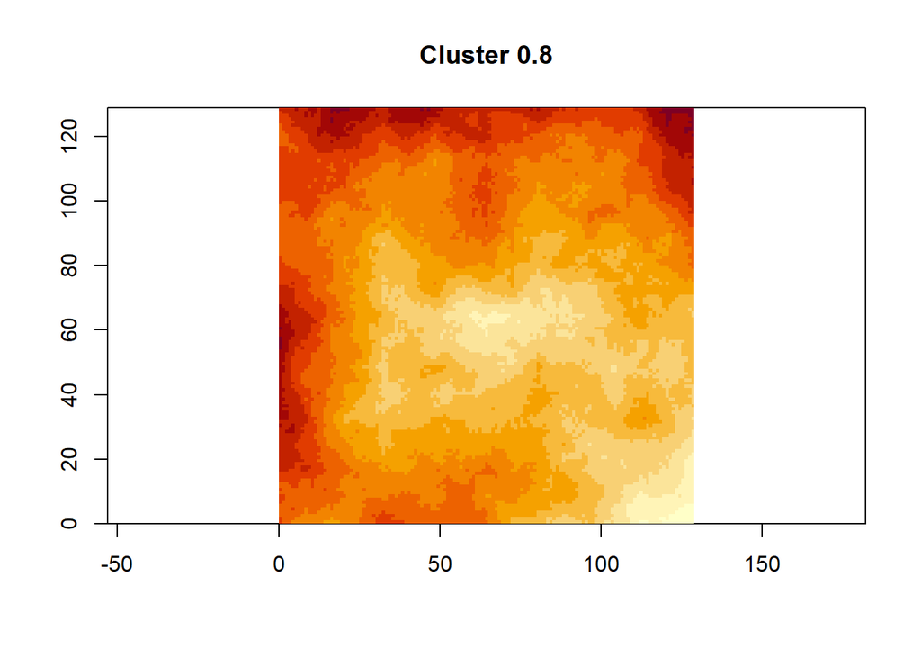

```r
# 8
voss8 = voss2d(g = 7, H = 0.8)
voss8 = rast(voss8$z)
image(voss8, main = "Cluster 0.8")
```

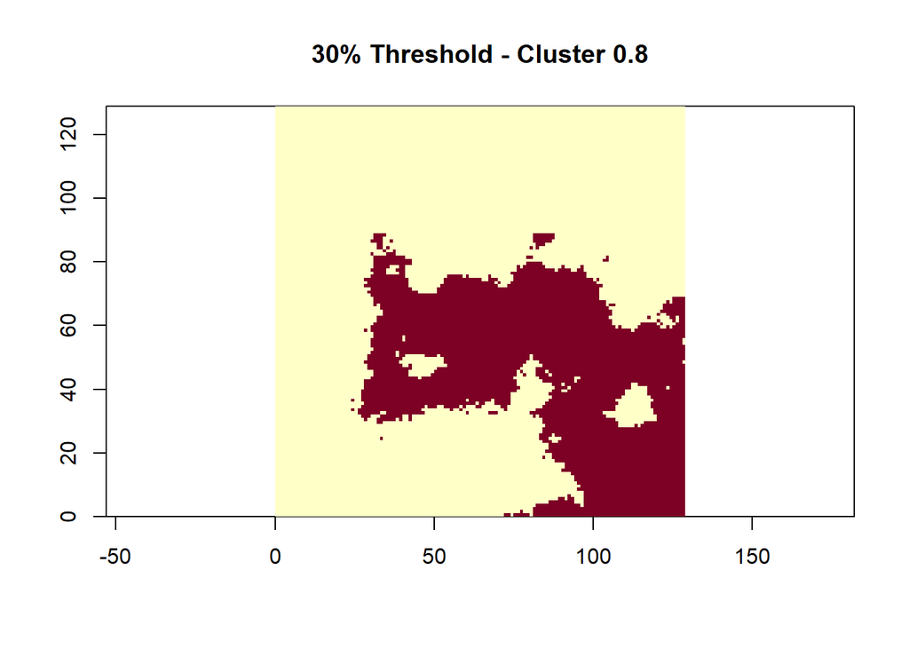

```r
thresholdv8 = quantile(as.matrix(voss8), prob = 0.3)
vossC8 = ifel(voss8 > thresholdv8, 0, 1)
image(vossC8, main = "30% Threshold - Cluster 0.8")
```

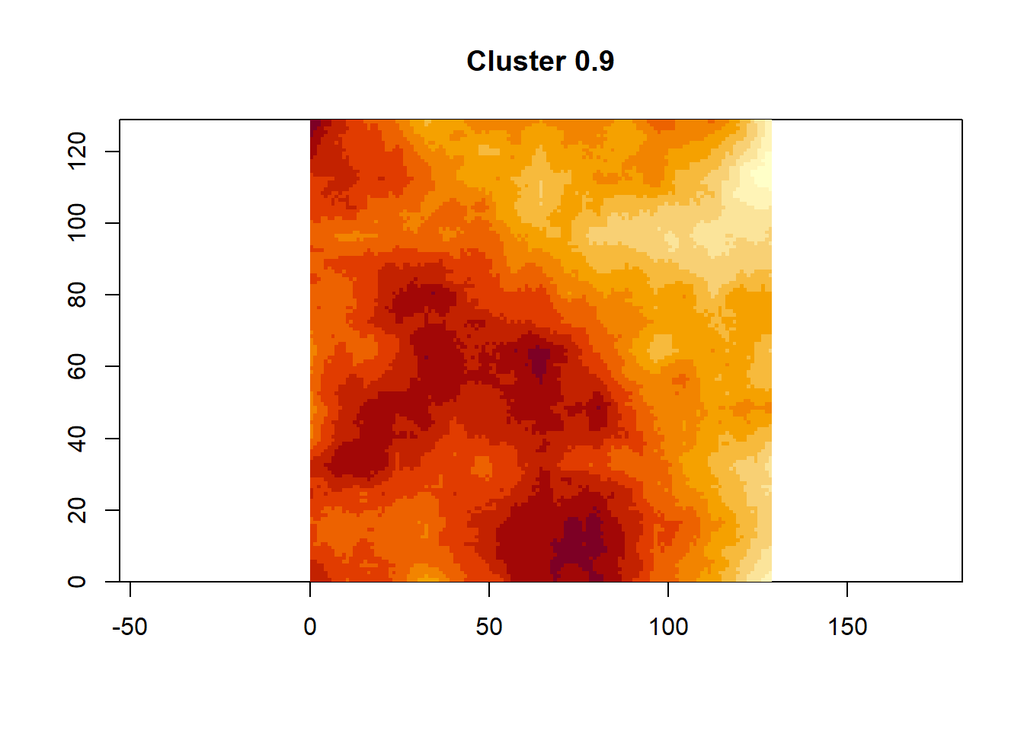

```r
# 9
voss9 = voss2d(g = 7, H = 0.9)
voss9 = rast(voss9$z)
image(voss9, main = "Cluster 0.9")
```

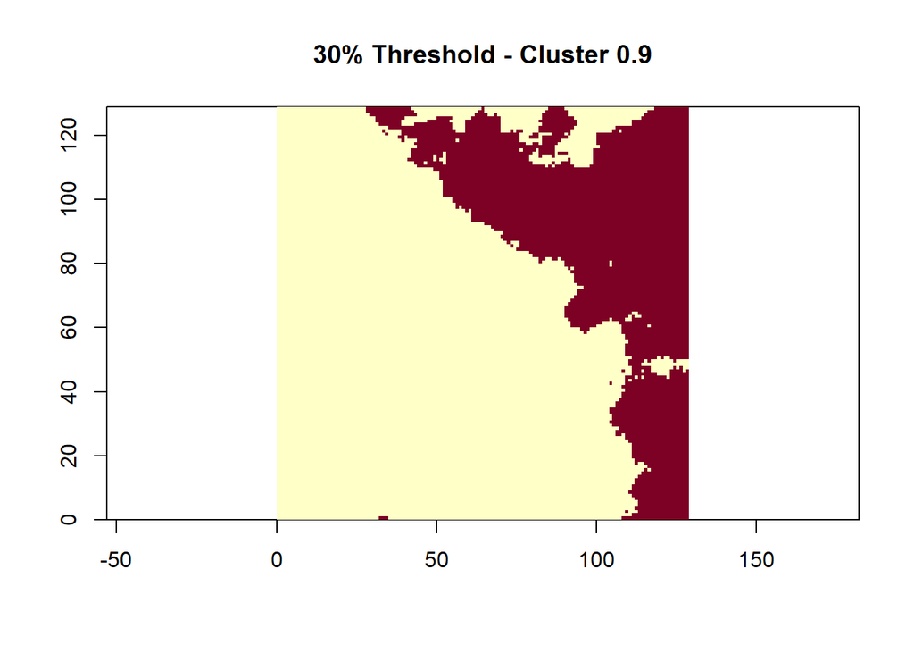

```r
thresholdv9 = quantile(as.matrix(voss9), prob = 0.3)
vossC9 = ifel(voss9 > thresholdv9, 0, 1)
image(vossC9, main = "30% Threshold - Cluster 0.9")
```

#### Comment on what patterns you see changing as the H value increases from 0.1 to 0.9

As the H value increases from 0.1 to 0.9, where the patches of cover show up on the map change. The major pattern observed is that as H increases, the number of patches decreases. However, because we held the cover to 30%, the amount is not changing, but instead the patches become closer and eventually merge.

**Identify 3 class-level or landscape-level metrics that help you capture the changes you are observing. THESE MUST BE DIFFERENT THAN THOSE METRICS YOU USED IN CHALLENGE 2. Calculate those metrics for each of the 9 landscapes and plot them (x-axis is H-value and y-axis is calculated metric).**

```r
# 1
lsm_l_condent(vossC1)
```

| layer | level | class | id | metric | value |
| --- | --- | --- | --- | --- | --- |
| 1 | landscape | NA | NA | condent | 0.6992841 |

```r
lsm_l_enn_mn(vossC1, directions =8)
```

| layer | level | class | id | metric | value |
| --- | --- | --- | --- | --- | --- |
| 1 | landscape | NA | NA | enn_mn | 2.467077 |

```r
lsm_l_gyrate_mn(vossC1, directions=8)
```

| layer | level | class | id | metric | value |
| --- | --- | --- | --- | --- | --- |
| 1 | landscape | NA | NA | gyrate_mn | 0.8477041 |

```r
# 2
lsm_l_condent(vossC2)
```

| layer | level | class | id | metric | value |
| --- | --- | --- | --- | --- | --- |
| 1 | landscape | NA | NA | condent | 0.589258 |

```r
lsm_l_enn_mn(vossC2, directions=8)
```

| layer | level | class | id | metric | value |
| --- | --- | --- | --- | --- | --- |
| 1 | landscape | NA | NA | enn_mn | 2.624688 |

```r
lsm_l_gyrate_mn(vossC2, directions=8)
```

| layer | level | class | id | metric | value |
| --- | --- | --- | --- | --- | --- |
| 1 | landscape | NA | NA | gyrate_mn | 0.8361187 |

```r
# 3
lsm_l_condent(vossC3)
```

| layer | level | class | id | metric | value |
| --- | --- | --- | --- | --- | --- |
| 1 | landscape | NA | NA | condent | 0.3807335 |

```r
lsm_l_enn_mn(vossC3, directions=8)
```

| layer | level | class | id | metric | value |
| --- | --- | --- | --- | --- | --- |
| 1 | landscape | NA | NA | enn_mn | 3.040124 |

```r
lsm_l_gyrate_mn(vossC3, directions=8)
```

| layer | level | class | id | metric | value |
| --- | --- | --- | --- | --- | --- |
| 1 | landscape | NA | NA | gyrate_mn | 1.117091 |

```r
# 4
lsm_l_condent(vossC4)
```

| layer | level | class | id | metric | value |
| --- | --- | --- | --- | --- | --- |
| 1 | landscape | NA | NA | condent | 0.4856028 |

```r
lsm_l_enn_mn(vossC4, directions=8)
```

| layer | level | class | id | metric | value |
| --- | --- | --- | --- | --- | --- |
| 1 | landscape | NA | NA | enn_mn | 2.511785 |

```r
lsm_l_gyrate_mn(vossC4, directions=8)
```

| layer | level | class | id | metric | value |
| --- | --- | --- | --- | --- | --- |
| 1 | landscape | NA | NA | gyrate_mn | 1.229614 |

```r
# 5
lsm_l_condent(vossC5)
```

| layer | level | class | id | metric | value |
| --- | --- | --- | --- | --- | --- |
| 1 | landscape | NA | NA | condent | 0.4581692 |

```r
lsm_l_enn_mn(vossC5, directions=8)
```

| layer | level | class | id | metric | value |
| --- | --- | --- | --- | --- | --- |
| 1 | landscape | NA | NA | enn_mn | 2.62304 |

```r
lsm_l_gyrate_mn(vossC5, directions=8)
```

| layer | level | class | id | metric | value |
| --- | --- | --- | --- | --- | --- |
| 1 | landscape | NA | NA | gyrate_mn | 1.24759 |

```r
# 6
lsm_l_condent(vossC6)
```

| layer | level | class | id | metric | value |
| --- | --- | --- | --- | --- | --- |
| 1 | landscape | NA | NA | condent | 0.4101379 |

```r
lsm_l_enn_mn(vossC6, directions=8)
```

| layer | level | class | id | metric | value |
| --- | --- | --- | --- | --- | --- |
| 1 | landscape | NA | NA | enn_mn | 2.736531 |

```r
lsm_l_gyrate_mn(vossC6, directions=8)
```

| layer | level | class | id | metric | value |
| --- | --- | --- | --- | --- | --- |
| 1 | landscape | NA | NA | gyrate_mn | 1.37869 |

```r
# 7
lsm_l_condent(vossC7)
```

| layer | level | class | id | metric | value |
| --- | --- | --- | --- | --- | --- |
| 1 | landscape | NA | NA | condent | 0.1904086 |

```r
lsm_l_enn_mn(vossC7, directions=8)
```

| layer | level | class | id | metric | value |
| --- | --- | --- | --- | --- | --- |
| 1 | landscape | NA | NA | enn_mn | 3.04674 |

```r
lsm_l_gyrate_mn(vossC7, directions=8)
```

| layer | level | class | id | metric | value |
| --- | --- | --- | --- | --- | --- |
| 1 | landscape | NA | NA | gyrate_mn | 2.793037 |

```r
# 8
lsm_l_condent(vossC8)
```

| layer | level | class | id | metric | value |
| --- | --- | --- | --- | --- | --- |
| 1 | landscape | NA | NA | condent | 0.181604 |

```r
lsm_l_enn_mn(vossC8, directions=8)
```

| layer | level | class | id | metric | value |
| --- | --- | --- | --- | --- | --- |
| 1 | landscape | NA | NA | enn_mn | 3.037467 |

```r
lsm_l_gyrate_mn(vossC8, directions=8)
```

| layer | level | class | id | metric | value |
| --- | --- | --- | --- | --- | --- |
| 1 | landscape | NA | NA | gyrate_mn | 3.354092 |

```r
# 9
lsm_l_condent(vossC9)
```

| layer | level | class | id | metric | value |
| --- | --- | --- | --- | --- | --- |
| 1 | landscape | NA | NA | condent | 0.1520156 |

```r
lsm_l_enn_mn(vossC9, directions=8)
```

| layer | level | class | id | metric | value |
| --- | --- | --- | --- | --- | --- |
| 1 | landscape | NA | NA | enn_mn | 5.546417 |

```r
lsm_l_gyrate_mn(vossC9, directions=8)
```

| layer | level | class | id | metric | value |
| --- | --- | --- | --- | --- | --- |
| 1 | landscape | NA | NA | gyrate_mn | 4.279755 |

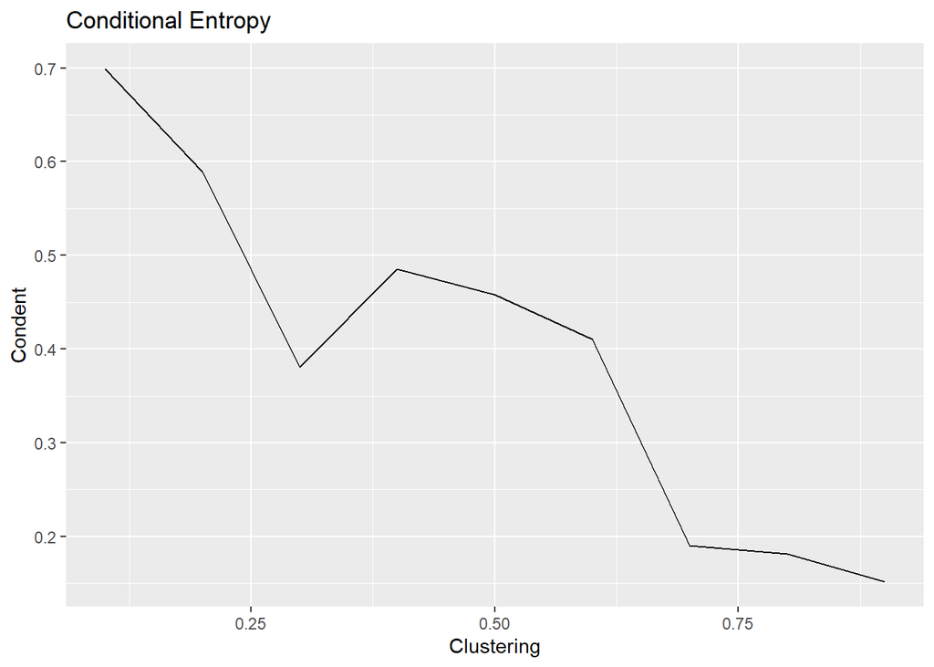

```r
LLclust <- data.frame(cluster = c(0.10, 0.20, 0.30, 0.40, 0.50, 0.60, 0.70, 0.80, 0.90),
                        condent = c(0.6992841, 0.589258, 0.3807335, 0.4856028, 0.4581692, 0.4101379, 0.1904086, 0.181604, 0.1520156),
                        enn_mn = c(2.467077, 2.624688, 3.040124, 2.511785, 2.62304, 2.736531, 3.04674, 3.037467, 5.546417),
                        gyrate_mn = c(0.8477041, 0.8361187, 1.117091, 1.229614, 1.24759, 1.37869, 2.793037, 3.354092, 4.279755))

plot_condent <- ggplot(LLclust, aes(x = cluster, y = condent)) +
  geom_line() +
  labs(title = "Conditional Entropy", x = "Clustering", y = "Condent")
plot_condent
```

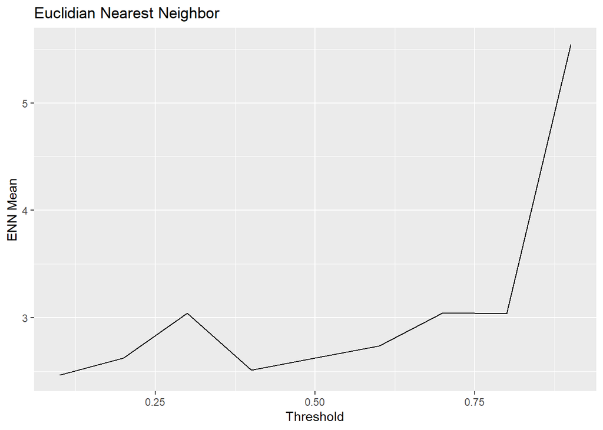

```r
plot_ennmn <- ggplot(LLclust, aes(x = cluster, y = enn_mn)) +
  geom_line() +
  labs(title = "Euclidian Nearest Neighbor", x = "Threshold", y = "ENN Mean")
plot_ennmn
```

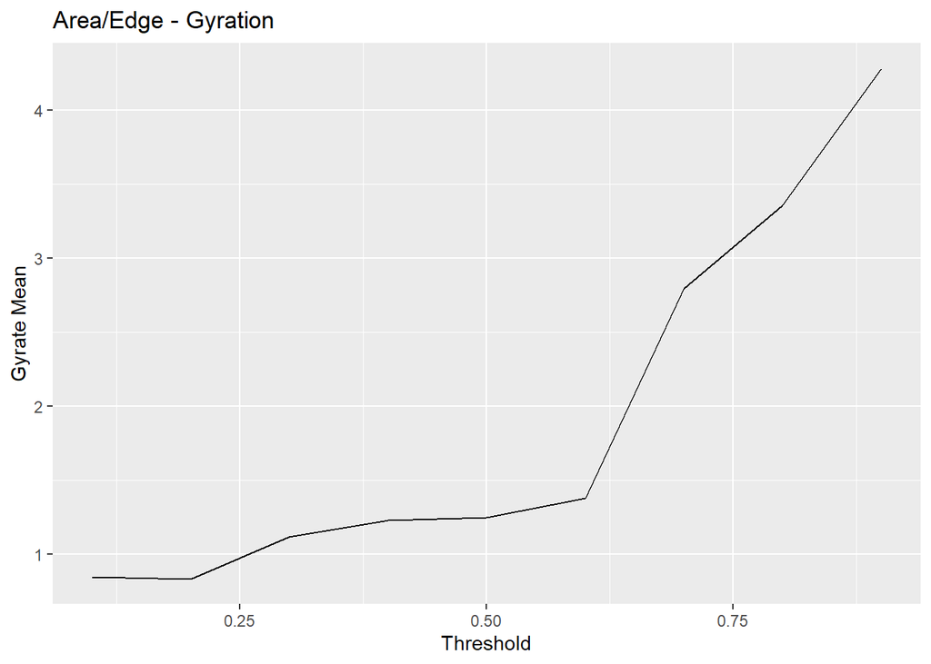

```r
plot_gyrate <- ggplot(LLclust, aes(x = cluster, y = gyrate_mn)) +
  geom_line() +
  labs(title = "Area/Edge - Gyration", x = "Threshold", y = "Gyrate Mean")
plot_gyrate
```

#### Briefly describe why you chose these 3 metrics and how they change with increasing cover.

Landscape Metrics 1. Conditional Entropy: I chose to use this metric because I wanted to see how complexity of the landscape changed over time as patches decreased. As the H value increased and the clustering of patches made the cover simpler the conditional entropy decreased. 2. Euclidean Nearest Neighbor Mean: I chose this metric because I anticipated that as the cover became more clustered, the distance between neighboring patches would decrease. However, the distance to neighbor increased gradually until around H=0.9 where it then increased rapidly. This is likely because the mean was at one time calculated between several close patches, but is now calculated between fewer patches that are spread out over a greater area. 3. Gyration Mean: I chose this metric because it is a more complex metric and I wanted to see how the distance between cells and the patch matrix would change as the number of patches decreased. As H increased, the gyration mean also increased.